```r
setwd("/Users/TARDIS/Documents/STUDIES/context_word_seg")
library(ProjectTemplate)
load.project()
```

# General descriptives

## How many utterances in each context?

```r
######
# WL #
######
WL <- df_WL %>%
  mutate_each(funs(ifelse(. > 0, 1, 0)), -utt, -orth, -phon)  # for word list analysis only, make all contexts either 1 or 0 (smoothing over 1.5's from expand_windows)

WL_sum <- data.frame(context = names(colSums(dplyr::select(WL, -utt, -orth, -phon))), n=colSums(dplyr::select(WL, -utt, -orth, -phon))) %>%
  mutate(method="word lists")
WL_sum %>%
  select(-method) %>%
  arrange(desc(n)) %>%
  kable()
```

| context | n |
| --- | --- |
| body_touch | 1530 |
| meal | 942 |
| fussing | 741 |
| bath | 664 |
| bed | 570 |
| play | 528 |
| diaper_dressing | 471 |
| media | 20 |

```r
######
# HJ #
######
HJ_sum <- data.frame(context=names(colSums(dplyr::select(df_HJ_bin, -utt, -orth, -phon), na.rm=TRUE)), n=colSums(dplyr::select(df_HJ_bin, -utt, -orth, -phon), na.rm=TRUE)) %>%
  mutate(method="coder judgments")
HJ_sum %>%
  select(-method) %>%
  arrange(desc(n)) %>%
  kable()
```

| context | n |
| --- | --- |
| playtime | 4780 |
| interaction | 4485 |
| fussing | 2706 |
| mealtime | 1832 |
| bathtime | 1230 |
| none | 941 |
| diaper change | 672 |
| dressing | 441 |
| sleep | 397 |
| housework | 291 |
| touching | 283 |
| taking pictures | 122 |
| hiccups | 80 |
| TV | 39 |
| outside | 36 |
| sick | 19 |
| coughing | 15 |
| stretching | 13 |
| sneezing | 12 |
| swimming | 12 |
| music | 10 |
| drooling | 4 |
| blowing bubbles | 2 |
| friends | 2 |
| pre-doctors visit | 1 |

```r
######
# TM #
######
LDA_sum <- data.frame(context=names(colSums(dplyr::select(df_LDA_bin, -utt, -orth, -phon), na.rm=TRUE)), n=colSums(dplyr::select(df_LDA_bin, -utt, -orth, -phon), na.rm=TRUE)) %>%
  mutate(method="LDA")
LDA_sum %>%
  select(-method) %>%
  arrange(desc(n)) %>%
  kable()
```

| context | n |
| --- | --- |
| topic_11 | 2292 |
| topic_5 | 1887 |
| topic_3 | 1616 |
| topic_4 | 1544 |
| topic_2 | 1478 |
| topic_7 | 1251 |
| topic_6 | 1187 |
| topic_9 | 1176 |
| topic_8 | 1090 |
| topic_12 | 1020 |
| topic_1 | 736 |
| topic_10 | 613 |

```r
STM_sum <- data.frame(context=names(colSums(dplyr::select(df_STM_bin, -utt, -orth, -phon), na.rm=TRUE)), n=colSums(dplyr::select(df_STM_bin, -utt, -orth, -phon), na.rm=TRUE)) %>%
  mutate(method="STM")
STM_sum %>%
  select(-method) %>%
  arrange(desc(n)) %>%
  kable()
```

| context | n |
| --- | --- |
| topic_3 | 2174 |
| topic_10 | 1938 |
| topic_4 | 1775 |
| topic_7 | 1733 |
| topic_1 | 1575 |
| topic_2 | 1392 |
| topic_8 | 1066 |
| topic_6 | 930 |
| topic_9 | 845 |
| topic_5 | 840 |
| topic_12 | 548 |
| topic_11 | 540 |

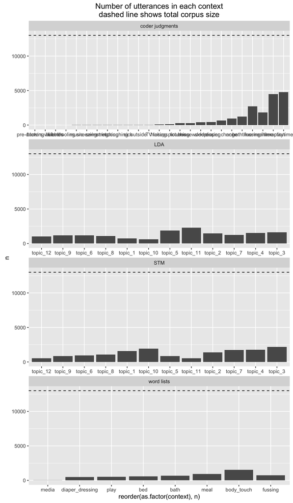

```r
all_sum <- rbind(WL_sum, HJ_sum, LDA_sum, STM_sum)

ggplot(all_sum, aes(y=n, x=reorder(as.factor(context), n))) +
  geom_bar(stat = 'identity', show.legend = FALSE) +
  geom_hline(aes(yintercept=nrow(df)), lty=2) +
  facet_wrap(~method, scales = "free_x", ncol=1) +
  ggtitle("Number of utterances in each context\ndashed line shows total corpus size")
```

## How many contexts per utterance?

```r
######
# WL #
######
WL$N.contexts <- rowSums(dplyr::select(WL, -utt, -orth, -phon))
table(WL$N.contexts)
```

```
##
##    0    1    2    3
## 8334 3924  693   52
```

```r
WL <- extract_contexts(WL)
summary(WL$context) # the number of utterances in each context
```

```
##       ambiguous            bath             bed      body_touch
##             745             440             377            1147
## diaper_dressing         fussing            meal           media
##             295             557             706              12
##  no context tag            play
##            8334             390
```

```r
length(which(WL$N.contexts > 2)) / length(WL$N.contexts) # percent of corpus with > 2 contexts
```

```
## [1] 0.003999077
```

```r
length(which(WL$N.contexts == 0)) / length(WL$N.contexts) # percent of corpus with 0 contexts
```

```
## [1] 0.640929
```

```r
length(which(WL$N.contexts > 2)) / length(which(WL$N.contexts > 0))
```

```
## [1] 0.01113729
```

```r
length(which(WL$N.contexts > 1)) / length(which(WL$N.contexts > 0))
```

```
## [1] 0.1595631
```

```r
######
# HJ #
######
df_HJ_bin$N.contexts <- rowSums(dplyr::select(df_HJ_bin, -utt, -orth, -phon), na.rm = TRUE)
table(df_HJ_bin$N.contexts)
```

```
##
##    0    1    2    3
##  501 6911 5259  332
```

```r
df_HJ_bin <- extract_contexts(df_HJ_bin)
summary(df_HJ_bin$context) # the number of utterances in each context
```

```
##       ambiguous        bathtime   diaper change        dressing
##            5591             877             292             148
##         fussing         hiccups       housework     interaction
##             794              18              99            1335
##        mealtime  no context tag            none         outside
##             772             501             171               4
##        playtime           sleep        sneezing taking pictures
##            2216             124               2              14
##        touching              TV
##              26              19
```

```r
length(which(df_HJ_bin$N.contexts > 2)) / length(df_HJ_bin$N.contexts) # percent of corpus with > 2 contexts
```

```
## [1] 0.02553257
```

```r
length(which(df_HJ_bin$N.contexts == 0)) / length(df_HJ_bin$N.contexts) # percent of corpus with 0 contexts
```

```
## [1] 0.03852957
```

```r
######
# TM #
######
df_LDA_bin$N.contexts <- rowSums(dplyr::select(df_LDA_bin, -utt, -orth, -phon), na.rm = TRUE)
table(df_LDA_bin$N.contexts)
```

```
##
##    0    1    2    3
##   31 9100 3350   30
```

```r
df_LDA_bin <- extract_contexts(df_LDA_bin)
summary(df_LDA_bin$context) # the number of utterances in each context
```

```
##      ambiguous no context tag        topic_1       topic_10       topic_11
##           3380             31            286            300           1440
##       topic_12        topic_2        topic_3        topic_4        topic_5
##            570            968            610           1065           1137
##        topic_6        topic_7        topic_8        topic_9
##            679            837            758            450
```

```r
length(which(df_LDA_bin$N.contexts > 2)) / length(df_LDA_bin$N.contexts) # percent of corpus with > 2 contexts
```

```
## [1] 0.00239789
```

```r
length(which(df_LDA_bin$N.contexts == 0)) / length(df_LDA_bin$N.contexts) # percent of corpus with 0 contexts
```

```
## [1] 0.00247782
```

```r
df_STM_bin$N.contexts <- rowSums(dplyr::select(df_STM_bin, -utt, -orth, -phon), na.rm = TRUE)
table(df_STM_bin$N.contexts)
```

```
##
##    0    1    2    3
##  213 9300 2938   60
```

```r
df_STM_bin <- extract_contexts(df_STM_bin)
summary(df_STM_bin$context) # the number of utterances in each context
```

```
##      ambiguous no context tag        topic_1       topic_10       topic_11
##           2998            213            621            936            390
##       topic_12        topic_2        topic_3        topic_4        topic_5
##            428            750           1432           1178            540
##        topic_6        topic_7        topic_8        topic_9
##            540           1256            766            463
```

```r
length(which(df_STM_bin$N.contexts > 2)) / length(df_STM_bin$N.contexts) # percent of corpus with > 2 contexts
```

```
## [1] 0.00479578
```

```r
length(which(df_STM_bin$N.contexts == 0)) / length(df_STM_bin$N.contexts) # percent of corpus with 0 contexts
```

```
## [1] 0.01702502
```

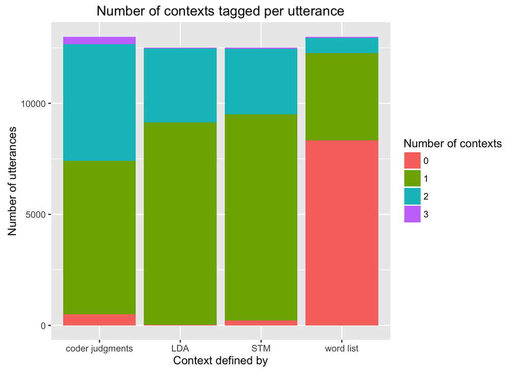

```r
###########
# OVERALL #
###########
wl_contexts <- dplyr::select(WL, utt, N.contexts, context) %>%
  mutate(method = "word list")
hj_contexts <- dplyr::select(df_HJ_bin, utt, N.contexts, context) %>%
  mutate(method = "coder judgments")
lda_contexts <- dplyr::select(df_LDA_bin, utt, N.contexts, context) %>%
  mutate(method = "LDA")
stm_contexts <- dplyr::select(df_STM_bin, utt, N.contexts, context) %>%
  mutate(method = "STM")

all_methods_counts <- rbind(wl_contexts, hj_contexts, lda_contexts, stm_contexts) %>%
  count(method, N.contexts)

ggplot(all_methods_counts, aes(y=n, x=method, fill=as.factor(N.contexts))) +
  geom_bar(stat = "identity") +
  labs(title = "Number of contexts tagged per utterance", y="Number of utterances", x = "Context defined by") +
  scale_fill_discrete(name="Number of contexts")
```

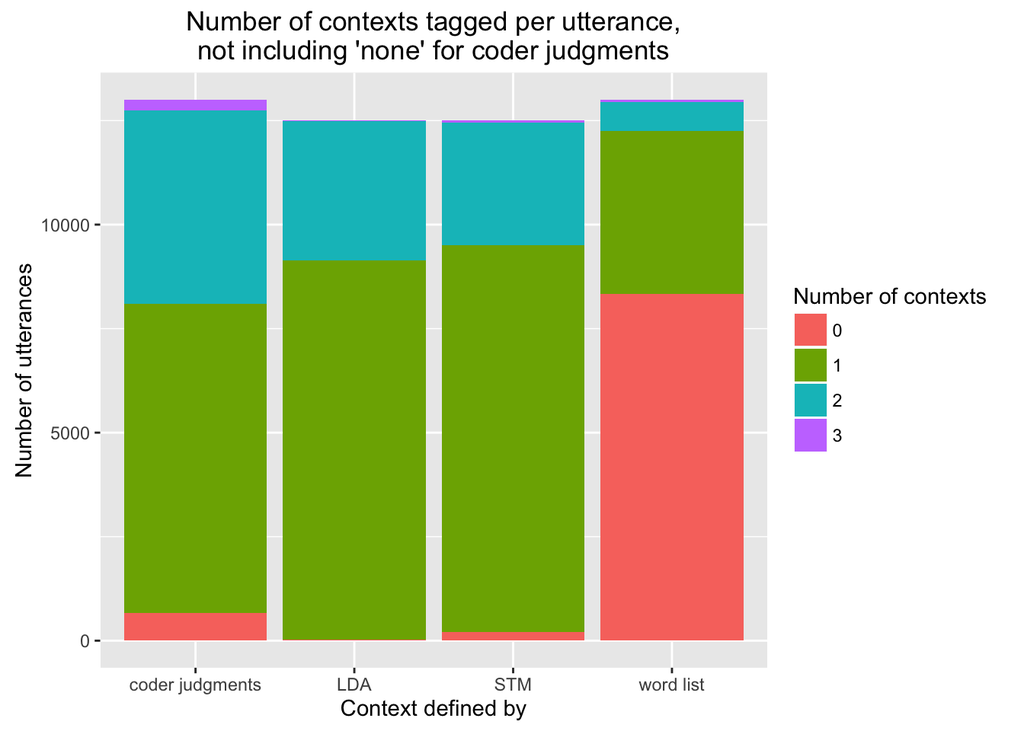

```r
df_HJ_bin_no_none <- dplyr::select(df_HJ_bin, -none, -N.contexts, -context)
df_HJ_bin_no_none$N.contexts <- rowSums(dplyr::select(df_HJ_bin_no_none, -utt, -orth, -phon), na.rm = TRUE)
df_HJ_bin_no_none <- extract_contexts(df_HJ_bin_no_none)

hj_no_none <- dplyr::select(df_HJ_bin_no_none, utt, N.contexts, context) %>%
  mutate(method = "coder judgments")

all_methods_counts_no_none <- rbind(wl_contexts, hj_no_none, lda_contexts, stm_contexts) %>%
  count(method, N.contexts)

ggplot(all_methods_counts_no_none, aes(y=n, x=method, fill=as.factor(N.contexts))) +
  geom_bar(stat = "identity") +
  labs(title = "Number of contexts tagged per utterance,\nnot including 'none' for coder judgments", y="Number of utterances", x = "Context defined by") +
  scale_fill_discrete(name="Number of contexts")
```

```r
table(hj_contexts$N.contexts)
```

```
##
##    0    1    2    3
##  501 6911 5259  332
```

```r
table(hj_no_none$N.contexts)
```

```
##
##    0    1    2    3
##  672 7429 4651  251
```

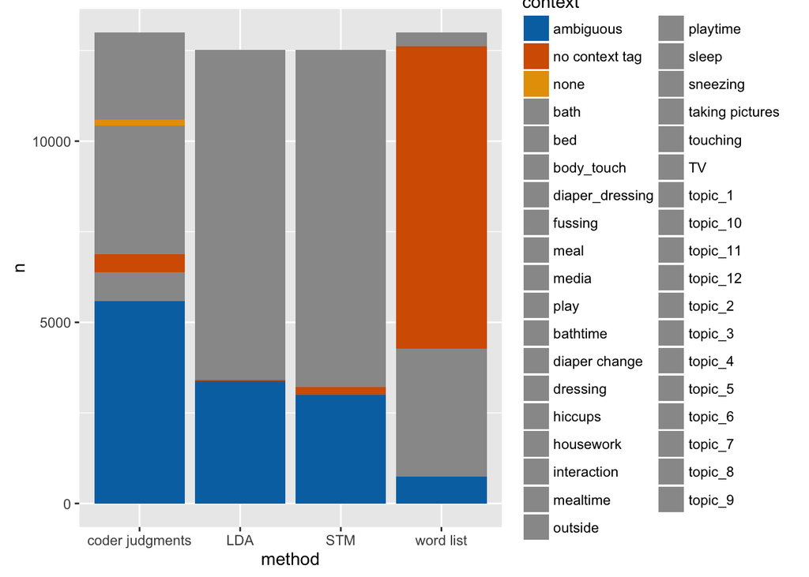

```r
all_methods_context_count <- rbind(wl_contexts, hj_contexts, lda_contexts, stm_contexts) %>%
  count(method, context)
all_methods_context_count$context <- relevel(all_methods_context_count$context, "none" )
all_methods_context_count$context <- relevel(all_methods_context_count$context, "no context tag" )
all_methods_context_count$context <- relevel(all_methods_context_count$context, "ambiguous" )

ggplot(all_methods_context_count, aes(y=n, x=method, fill=context)) +
  geom_bar(stat= "identity") +
  scale_fill_manual(values = c("#0072B2", "#D55E00", "#E69F00", rep("#999999", length(levels(all_methods_context_count$context)) - 3)))
```

Printing context files for sharing with CF:

```r
all <- rbind(wl_contexts, hj_no_none, lda_contexts, stm_contexts) %>%
  dplyr::select(utt, context, method) %>%
  tidyr::extract(utt, into = c("child", "age", "utt.num"), regex = "^([[:alpha:]]{2})([[:digit:]]{2})[.]cha_([[:digit:]]+)$")

all$utt.num <- as.numeric(all$utt.num)

all %>%
  dplyr::filter(method=="word list") %>%
  tidyr::spread(key=utt.num, value=context) %>%
  dplyr::select(-method) %>%
  write.csv("/Users/TARDIS/Dropbox/2_RoseM_TP/context_files/contexts_file_WL.csv", row.names=FALSE)
all %>%
  dplyr::filter(method=="coder judgments") %>%
  tidyr::spread(key=utt.num, value=context) %>%
  dplyr::select(-method) %>%
  write.csv("/Users/TARDIS/Dropbox/2_RoseM_TP/context_files/contexts_file_HJ.csv", row.names=FALSE)
all %>%
  dplyr::filter(method=="LDA") %>%
  tidyr::spread(key=utt.num, value=context) %>%
  dplyr::select(-method) %>%
  write.csv("/Users/TARDIS/Dropbox/2_RoseM_TP/context_files/contexts_file_LDA.csv", row.names=FALSE)
all %>%
  dplyr::filter(method=="STM") %>%
  tidyr::spread(key=utt.num, value=context) %>%
  dplyr::select(-method) %>%
  write.csv("/Users/TARDIS/Dropbox/2_RoseM_TP/context_files/contexts_file_STM.csv", row.names=FALSE)
```

## Select context files to use

Dropping “none” codes from HJ.

```r
WL <- WL
HJ <- df_HJ_bin_no_none
LDA <- df_LDA_bin
STM <- df_STM_bin
```

## General thoughts

The word list and coder definitions of context naturally produce a skewed distribution of activities, whereas the topic modeling approaches discover a more uniform distribution of activities. To the extent that the distritbution of activities is naturally skewed (e.g. that a few activities happen very often, and many others happen rarely), topic modeling approaches to identifying activity context may distort reality.

# Word list descriptives

## Frequency of WL key words?

```r
contexts <- names(WL_contexts)
WL_context_data <- data.frame(NULL)
for(k in contexts){
  WL_context_data <- rbind(WL_context_data, data.frame(word=WL_contexts[[k]], context=k, stringsAsFactors = FALSE))
}

orth_stream <- paste(df$orth, collapse = " ")
# flag bigrams from WL keywords in orth stream, so they don't get separated
for(w_bar in grep(x = WL_context_data$word, pattern = "_", value=TRUE)){
  w_space <- gsub(x=w_bar, pattern="_", replacement=" ")
  orth_stream <- gsub(x=orth_stream, pattern = w_space, replacement = w_bar)
}

orth_stream <- strsplit(orth_stream, split=" ")[[1]]
orth_stream <- orth_stream[orth_stream != ""]

orth_data <- data.frame(word=orth_stream, stringsAsFactors = FALSE) %>%
  count(word)

WL_context_data <- left_join(WL_context_data, orth_data, by="word") %>%
  arrange(context, n)

WL_context_data %>%
  group_by(context) %>%
  summarise(total=sum(n, na.rm=TRUE),
            mean.freq=mean(n, na.rm=TRUE),
            highest=max(n, na.rm=TRUE),
            which.highest=word[which.max(n)]) %>%
  kable()
```

| context | total | mean.freq | highest | which.highest |
| --- | --- | --- | --- | --- |
| bath | 287 | 15.105263 | 47 | bath |
| bed | 150 | 13.636364 | 43 | tired |
| body_touch | 550 | 20.370370 | 123 | tickle |
| diaper_dressing | 116 | 6.444444 | 50 | nappie |
| fussing | 216 | 19.636364 | 56 | ssh |
| meal | 303 | 8.416667 | 27 | eat |
| media | 4 | 2.000000 | 3 | television |
| play | 136 | 7.157895 | 65 | play |

# HJ

## Do “none” contexts from HJ match utterances with 0 context codes from WL?

```r
df_HJ_none <- df_HJ_bin
df_HJ_none$HJ_none <- ifelse(df_HJ_none$none==1, 1,
                             ifelse(df_HJ_none$none==0, 0, NA))
df_HJ_none <- dplyr::select(df_HJ_none, utt, HJ_none)

df_WL_0 <- WL
df_WL_0$WL_0 <- ifelse(df_WL_0$N.contexts == 0, 1,
                             ifelse(df_WL_0$N.contexts > 0, 0, NA))
df_WL_0 <- dplyr::select(df_WL_0, utt, WL_0)

match <- full_join(df_HJ_none, df_WL_0, by="utt") %>%
  mutate(match = HJ_none + WL_0)
match$match <- ifelse(match$match == 2, 1,
                      ifelse(match$match < 2, 0, NA))
nrow(df_WL_0); nrow(df_HJ_none); nrow(match)
```

```
## [1] 13003
```

```
## [1] 13003
```

```
## [1] 13003
```

```r
tab <- xtabs( ~ WL_0 + HJ_none, data = match)

addmargins(tab)
```

```
##      HJ_none
## WL_0      0     1   Sum
##   0    4395   188  4583
##   1    7406   753  8159
##   Sum 11801   941 12742
```

```r
summary(tab)
```

```
## Call: xtabs(formula = ~WL_0 + HJ_none, data = match)
## Number of cases in table: 12742
## Number of factors: 2
## Test for independence of all factors:
##  Chisq = 112.78, df = 1, p-value = 2.41e-26
```

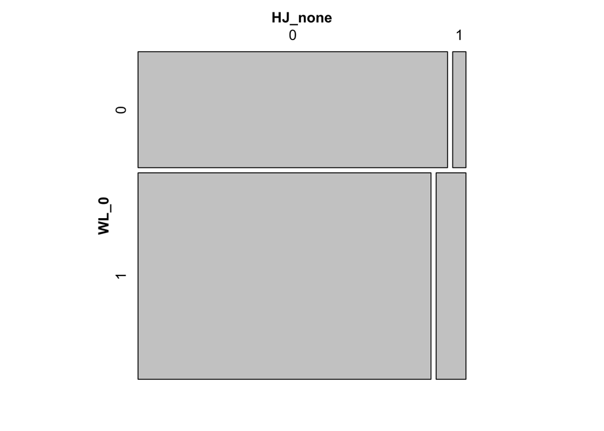

```r
mosaic(tab)
```

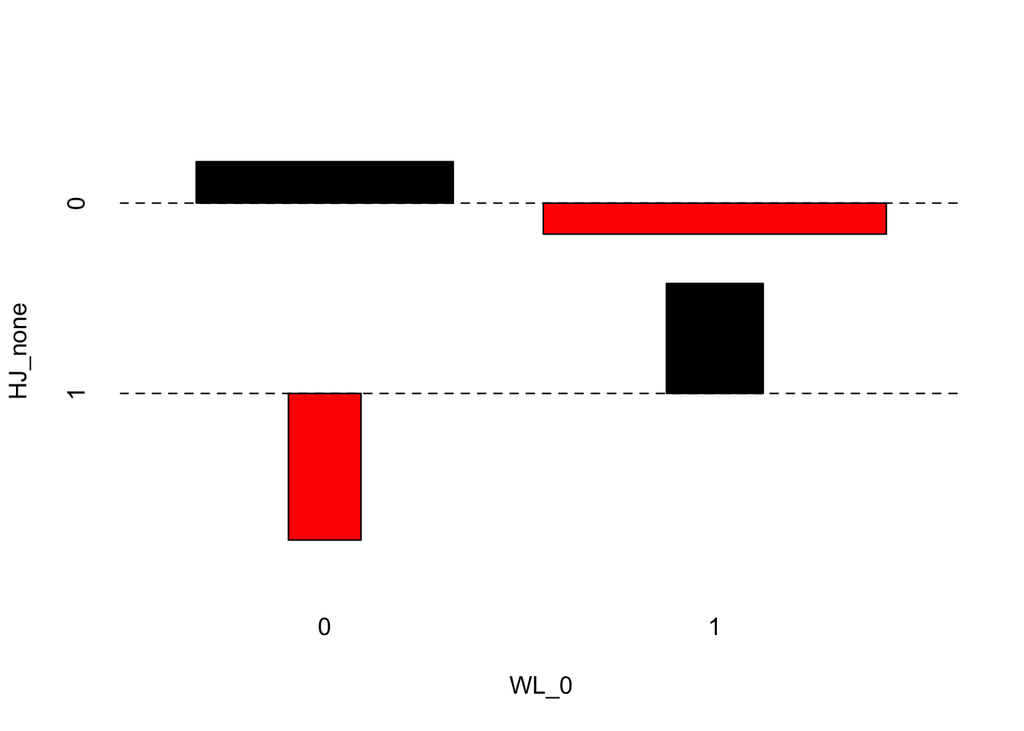

```r
assocplot(tab)
```

```r
assocstats(tab)
```

```
##                     X^2 df P(> X^2)
## Likelihood Ratio 122.91  1        0
## Pearson          112.78  1        0
##
## Phi-Coefficient   : 0.094
## Contingency Coeff.: 0.094
## Cramer's V        : 0.094
```

What percent of the “none” context utterances in HJ method are 0 context in WL?

```r
sum(match$match, na.rm=TRUE) / sum(match$HJ_none, na.rm=TRUE)
```

```
## [1] 0.8002125
```

What percent of the 0 context utterances in WL method are “none” context in HJ?

```r
sum(match$match, na.rm=TRUE) / sum(match$WL_0, na.rm=TRUE)
```

```
## [1] 0.09035277
```

# Topic modeling: LDA

# Topic modeling: STM

What words are associated with each STM topic?

```r
summary(stm)
```

A topic model with 12 topics, 427 documents and a 531 word dictionary. Topic Words: Topic 1: side, lost, dear, round, ha, said, teddi Topic 2: bop, hello, monkey, give, hi, thing, say Topic 3: shh, hey, shake, rabbit, els, chou, light Topic 4: door, lunch, minut, sit, lucki, sweetheart, watch Topic 5: tickl, toe, feet, din, tick, tum, boy Topic 6: away, one, nappi, will, wee, sorri, milk Topic 7: hair, water, bad, fun, minut, deari, drink Topic 8: bum, bath, splash, swim, shake, dad, mum Topic 9: boo, bye, ah, clever, hide, see, tea Topic 10: hand, see, naughti, fed, can, bite, look Topic 11: juic, whether, duck, quack, miss, leav, madam Topic 12: dear, got, oh, hello, shame

Covariate Words: Group cr: grumpi, gut, gorgeous, hmm, full, fast, shall Group gi: jumper, throat, without, keep, christoph, bash, reach Group gl: precious, handi, snooz, temper, mat, slept, happi Group la: hannah, busi, usual, nosh, prove, mummi, whose Group st: mobil, oven, cradl, appl, pussycat, cupsi, shoulder

Topic-Covariate Interactions: Topic 1, Group cr: pretti, forget, nail, whee, let, dress, tear Topic 1, Group gi: clap, hand, hiccough, might, hah, christoph, left Topic 1, Group gl: struggl, walk, lost, aw, danc, punch, chin Topic 1, Group la: dub, bib, dear, bath, someth, hurt, whee Topic 1, Group st: hmm, stuck, okay, push, myron, kick, camera

Topic 2, Group cr: ticki, shake, excit, bore, gillian, chou, camera Topic 2, Group gi: oop, us, stuff, bash, christoph, hello, friend Topic 2, Group gl: hmm Topic 2, Group la: pretti, skirt, seen, sunshin, kick, hello, bop Topic 2, Group st: foot, attent, grab, must, nose, matter, play

Topic 3, Group cr: shush, matter, pleas, dolli, gillian, ah, hey Topic 3, Group gi: littl, re, wind, kick, shake, lad, chou Topic 3, Group gl: bop, rest, talk, oop, tri, bore, bib Topic 3, Group la: polli, near, thank, oop, bubbl, treasur, ho Topic 3, Group st: food, swing, smile, myron, suppos, move, ssh

Topic 4, Group cr: girl, love, nose, bubbl, littl, bless Topic 4, Group gi: gonna, lad, ticklish, clean, never, mum, hous Topic 4, Group gl: first, know, ssh, stuff, wet, will, happen Topic 4, Group la: iron, arm, downstair, cuddl, god, mm, quiet Topic 4, Group st: daddi, goin, readi, burp, wind, ya, wash

Topic 5, Group cr: belli, soft, wee, stori, din, nose, shout Topic 5, Group gi: clever, parrot, yum, complain, sack, daisi, terribl Topic 5, Group gl: find, tum, old, hah, dinner, thumb, lie Topic 5, Group la: excit, three, beebo, two, tum, get, one Topic 5, Group st: feet, toe, boy

Topic 6, Group cr: sleepi, huh, head, shout, dolli, eye, chair Topic 6, Group gi: burp, suck, vest, carri, roll, bib, finger Topic 6, Group gl: hide, astra, three, ah, daisi, hiccup, chang Topic 6, Group la: sunshin, clean, wee, straight, nappi, morn, one Topic 6, Group st: charl, bib, ever, gonna, forget, tri, whee

Topic 7, Group cr: gonna, tell, cross, patch, shout, madam, stori Topic 7, Group gi: fatti, relax, grab, ow, walk, lift, dad Topic 7, Group gl: petal, tale, pop, pet, bath, wash, dirti Topic 7, Group la: dub, stori, tell, daddi, rub, mum, wash Topic 7, Group st: lulu, hot, bottl, wide, juic, garden, first

Topic 8, Group cr: bath, bum Topic 8, Group gi: arm, struggl, naughti, stick, nail, wash, let Topic 8, Group gl: stori, wee, bubbl, next, ha, aw, mess Topic 8, Group la: will, splish, splosh, tonight, whee, air, mm Topic 8, Group st: say, anyth, cuddl, myron, shake, milk, hello

Topic 9, Group cr: oop, cross, patch, shush, sack, re, babi Topic 9, Group gi: parrot, everyth, best, mouth, cup, teeth, hair Topic 9, Group gl: astra, myron, anoth, tomorrow, yeah, clean, one Topic 9, Group la: lambchop, sleepi, watch, chou, love, girl, tri Topic 9, Group st: hide, stand, ah, littl, bye

Topic 10, Group cr: toe, stretch, game, play, can, tongu, goin Topic 10, Group gi: clap, splash, shout, push, stand, soon, ya Topic 10, Group gl: pretti, pram, can, bear, afternoon, play, tell Topic 10, Group la: lambchop, chou, friend, littl, smile, hmm, daddi Topic 10, Group st: polli, lewi, pastri, joseph, rain, though, thank

Topic 11, Group cr: attent, ya, bib, matter, think, minut, alright Topic 11, Group gi: duck, quack, bath, will, look, left, minut Topic 11, Group gl: get, sunshin, dress, tongu, arm, stori, never Topic 11, Group la: paddi, donald, yum, quack, came, point, silli Topic 11, Group st: meringu, dub, pie, lemon, rub, joseph, cupboard

Topic 12, Group cr: shame, burp, fatti, hicki, mind, poor, never Topic 12, Group gi: nose, stretch, daddi, size, christoph Topic 12, Group gl: smile, daddi, dad, bless, tis, stay, girli Topic 12, Group la: ssh, trea, pie, alright, armi, darl, funni Topic 12, Group st:

```r
findThoughts(stm, TM_doc_prep_out$meta$documents)
```

Topic 1: you are so you’re taking an awful interest in what’s going on you are so you’re taking too big an interest in what’s going on yes ha ha oh struggle struggle struggle oh dear oh dear oh dear yes oh she’s lost up up up up up oh she’s lost she’s lost there she is there she is oh oh hold that finger oh dear dear dear dear oh there there there there have a kick go on dance you will you’ll pull it all out i’ll have none left i’ll have none left goodness me oh is that true oh goodness then what happened really oh dear you going to clap ya hands clap ya hands clap ya hands go on clap your hands clap your hands that’s it clap hands you do it yes clap your hands oh well clap your hands that’s it clap your hands go on are you trying to reach my hands look hold that hand and that hand and that one there yes oh oh dear oh no no no no oh oh oh you’re going for a walk are you going to go for a walk are you where you going where you going where are you going to go where you going to walk to where are you going to walk to hey hey where is it where is it to be we going out to play  
Topic 2: hello hello oh what’s that grunt for &hmm is it you’re excited are you excited are you excited about the monkey are you hello hello gillian poor funny face what a funny face your face is funnier than his yes it is hello what’s that and a funny face too and a funny face yes it is funny face hello there hello what’s this &hmm that a monkey whee hello gillian hello who’s that who’s that hello christopher well then oop you’re not looking are you oop well oop whee whee oop hello hello just here is it yes you happy yes oop who’s this a new friend well hello you’re supposed to like this give us some smiles this is it hey hello hello hello hello hello hello that’s a funny face like a monkey look what’s this what’s this then hello gillian hello whee hello hello &hmm where’s it gone oh is it on your head is it oh you don’t like that do ya you don’t like the monkey being on your head &hmm shake hands shake hands hello gillian say that’s your monkey hello hello then what’s this you saw this the last time didn’t you &hmm hello your not quite interested quite interested &hmm there we are i’ll give you a kiss  
Topic 3: oh dear it’s a hard life isn’t it what is it hey hey hey hey hey smile for mummie there nearly not quite was that really a cry hey hey hey hey hey hey hey hannah oh where ya goin look up up up up up up there’s a teddy hannah hold it hannah oh yes there look oh oh oh hey again oh what chou messing about with me for is that what you’re there oh nearly hey hey yes you can i know you can oh dear oh dear oh well have a little bounce have a little bounce that’s good have a little bounce hey hey bouncie bouncie well you don’t think much of that do you is it warm for you is it well well then come on help me kick kick kick kick kick kick kick kick have a kick beep have a kick hey have a kick yes that’s it have a go have a go well then come on punch that nose punch that nose yes yes do so yes you do so yes punch your mummie yes come on yes is it over sleepy bones over there is so hey here we go happy as you are you are so hey oh is that an aeroplane did you hear it did you hear that aeroplane hey hey come on then hey move that teddy that teddy’s gone to sleep  
Topic 4: &eh come on then come on then are you snorting hannah mummie’s still waiting for a windy and you’ve gone fast asleep fast &mm come on come on &mm come on hannah come on sweetheart there must be a big windy somewhere mummie’s sitting reading the paper while you snoozing away &mm come on come on darling &mm come on can we have a big burps please a big windy &eh &eh &mm &eh mummy’s tired too &mm come on come on come on come on sweetheart yes she has yes she has sweetheart &mm &mm yes yes who’s a good girl who’s a good girl there’s a good girl there’s a good girl &mm aren’t we quiet now &mm in mummy’s arms &eh is that nice having a cuddle with your mummy i love my mummy and my mummy loves me yes we do don’t we darling &mm &eh &mm oh you are a quiet girlie aren’t you now &mm quiet girlie in mummy’s arms &eh &eh darling &mm that was a big sigh yes you alright there’s a good girl there there there yes you’re alright are you going to watch the tennis for five minutes hey will you watch the tennis for five minutes will you hey you’re wet you are so it is so soaking soaking soaking you’re soaked there you are you sit there i am going to put your tea on i am so you’ll be a good girl until i come back will you be a good girl until i come back will you now i’ll turn you around and you can watch the tennis there you are there you are you sit there and tell me what’s happening you sit there and tell me what’s happening here you are darling i know you’ve been a good yes darling i know i know darling i know darling yes i know you’ve been a good girl there there there there there there there i know you’ve been a good girl  
Topic 5: clever boy yes you clever boy are you a clever boy are you a clever boy you are you’re clever you’re clever are you going to walk over to me oh clever you silly thing i know &ah tickle tickle tickle tickle tickle tickle tickle &ah tickle tickle tickle tickle tickle tickle tickle &ah tickle tickle tickle tickle tickle tickle tickle &ah tickle tickle tickle tickle tickle tickle tickle my goodness who’s a big gargler what’s this christopher chris what’s this your feet have you seen your feet today christopher have you seen your feet today have you i bet you haven’t have you come on then oh whoops whee come on yes yes who’s got a big belly who’s got a big belly who’s got a big belly yes who’s got a big belly who’s got the biggest belly in the house who’s got the biggest belly in the house who’s shouting &eh who’s shouting about it who’s shouting about it is it you is it shall we put your drawers back on shall we shall we put your drawers back on shall we shall we oh whee oh that’s nice oh yes oh yes oh does that tickle does that tickle tickle tickle tickle daddy’s playing with our new washing machine oh there oh what a misery what a misery guts tickle tickle tickle tickle tickle tickle tickle tickle tickle tickle tickle tickle tickle tickle tickle tickle tickle tickle tickle tickle tickle tickle tickle tickle tickle tickle yes my goodness have you given that parrot a telling off have you i’ll put him on what’s he done to you what’s he done hey what’s he done tickle tickle tickle tickle tickle tickle tickle hey what did he do my goodness you’re not doing it to him are you poor parrot deserves a certain warning it’s enough i think you don’t like him do we care phrooo^hey go on that’s it ahh^phroooo parrots can’t do that oops oops a daisy ahh^phroooo hick  
Topic 6: you do it you do it come on yes come on burp come on you do it try it well you can blow bubbles though can’t you well do you think i shouldn’t do it or should i drink it again you do it come on it’s not so difficult you do it yes come on yes come on then no i didn’t say suck my fingers i didn’t we’ll have no fingers left if we carry on like this you know they’ll be sucked away to the bone they will sucked away to the bone makes you sick to chew your fingers doesn’t it it does makes you sick to chew them down your throat do you want to do a bubble come on there she is again where’s she gone there she is has anybody seen astra has anybody seen astra cause she has gone away cause she has gone away yes one two three wee you’re hiding there you are you hide under there and have a nice nap where is she there she is again where’s she gone there she is shoes on tied them in a knot that wasn’t a very clever mother was it no &ah &ah &ah you want to wrestle now i’ll win you want to wrestle i’ll win i am bigger than you yes i am bigger than you yes i am bigger than you one two three there oh it’s a pretty underskirt are you come on then take your jacket off well oh good you can’t go on the round the world tour with no nappie on you know no how did you get down there you can’t talk with your mouth full of fingers are you going to roll over &eh going to roll over hello alright go on then roll over come on come on you come here you come over here come on come and see me then come on what are you doing with your feet are you having a big kick who’s having a big kick do ya want your jumper and vest off too do ya come on then you roll over here you roll over here  
Topic 7: here poppit oh dear oh dear oh dear up you come oh oh you’ve had a long sleep have you had a long sleep oh dear oh dear just a minute just a minute oh dear oh oh oh oh oh dear &ah did you think i would put you back there did you oh dear have you got windies come here darling come on petal have you got windy pops oh come on you’re a good girl where are those windy pops where are those windy pops where are they where are those windy pops come on oh dear that’s not very good no carrying on like that drinking all your drinks eating all your food dear i should sack them no you can’t get good servants nowadays can you my goodness that price well you’d think it was a privilege you’d think they’d think that wouldn’t you it’s a privilege working for you don’t want wages as well do they my goodness oh dear oh yes oh dear yes oh deary me yes but did you enjoy yourself really did you did you enjoy yourself oh dear and did we go to the seaside on monday did we yes we did yes we did yes oh yes and then change your nappie and then you’ll be ready to go oh that’s a funny noise it is what does that little noise mean does it mean you’d like some more well you’ve got just a tiny little mouthful in here let’s see oh it well i’ll tell you what we’ve got to do is warm it up first so if i do your hot water bottle at the same time you’ll have to sleep put ya mobile on shall we come on then just wait five minutes there we are put ya down there for a minute uh-huh we’ll play ya mobile shall we yeah play ya mobile i’ll put your hot water bottle in the pram have your juice and then we’ll go out in the garden come on then lulu come on then lulu come and have a drink yes come on drink time come on then baby come and have ya drink then we’ll change you then you can come outside and help mummie can’t you yes  
Topic 8: swim swim swim swim swim swim &eh swim swim &mm oh isn’t that nice i’m swimming i’m swimming i’m swimming &mm splash splish &eh whee whee whee &mm i say you going to be a good girl for mummy tonight are you you going to sleep &eh are you are you going to be a good girl for your mummy tonight and go to &eh not a half past nine job again &mm did you say yes then did you say yes then you’ve done it to your mummie this time yes you have so you’ve no bubbles now you got your mummie in a mess yes you’ve no bubbles now you got your mummie messed up yes come on then read the nice stories this is a nice story read your nice story are you going to sit up a wee bit oh that thumb that thumb is that an awful good thumb is it is that an awful good thumb hey come on then these are good stories today yes they are so these are good stories today yes come on then what did you do next yes what did you do next hey what was it no you don’t eat that no you don’t eat the wire leave it go hannah &eh &eh &mm isn’t that lovely &mm isn’t that lovely say mummie wash you oh whee can mummy wash under your big fat chin can mummy wash under your big fat chin &mm no she can’t can she there’s a girl kickello kickello there isn’t that nice &mm yes it is &mm &mm good girl yes hannah splash cause hannah likes to splash &mm oh splish splish splosh splish whee  
Topic 9: have you got hiccoughs there the second time today hey you do it come on yes yes you can that’s it you clever boy come on keep at it yes you’re the best at blowing bubbles of course you are i know you’re best , you’re better than me what yes oh well what’s going on in there well well you’re not going to change thumbs &ah boo boo boo &ah boo boo boo you do it boo boo boo boo boo boo boo boo boo boo boo boo you do it come on make the noise boo boo boo are ya hot boo boo boo boo boo hello hello hello hello shush shush shush shush oh dear you’ve banged yourself again haven’t you haven’t you &ah come here come here then cross patch come here cross patch oh there we are hello hello then hello cross patch baby hello hello cross patch baby alright what then is it tea time is it is it tea time &hmm and what do you want for tea and what do you like for tea oh oh oh i can’t i can’t see them i can’t i can’t see them i can’t see them i can’t see them no i can’t see them i can’t i can’t see them no i can’t i can’t see them i can’t see them no no i can’t no i can’t i can’t i can’t see them no no no no no oh what’re you doing &hmm what’re you doing then &hmm what’re ya doing hello hello hello hello hello boo boo boo boo  
Topic 10: you think you can rattle your foot up and down it’s on your foot isn’t it where’s it gone where’s it gone it’s here look it’s on your foot it’s there look that’s it if you move your foot it makes a noise that’s right yeah now are you going to take it in your hands come on take him in your hand you hold him that’s it you hold him and put it in your mouth that’s right you going to put that end in your mouth that’s a plastic bear isn’t it want to take him again that’s it good boy see if you can find your mouth that’s it that’s it that’s it rattle it up and down good boy isn’t he nice that’s the bear’s head yeah it’s nice it’s if you touch the yellow ball it makes it rattle that’s right want to prop it in your mouth again can you find your mouth look there we are yes they’re in there they are so they’re there yes they are so yes what ya what’s that can you see the pretty colors can you see the pretty colors can you can you see those pretty colors &hmm can you see those pretty colors yes yes yes tell me tell me are you going to go out in your pram in the afternoon are you going out in your pram are you going out in your pram yes and have a sleep and give mum some peace yes you’re going to give mum some peace really i don’t want to go to sleep you slept all night didn’t you you’d do you want those do you want to read that recipe cause next time we cook mummie thinks she is going to make that what do you think are you going to are you tasting it to see what and what do you think do you like that recipe best of all shall we do that one next time is that a recipe from our stew cupsy is that a recipe from our stew you have to watch polly isn’t that funny don’t it feel funny they’re polly’s paws feel polly’s paws on ya her paws are lovely and soft aren’t they but don’t no don’t bite them i don’t think polly’d be pleased isn’t that nice like a little soft toy isn’t she and she’s warm isn’t she enjoying this aren’t you yes you a bit fed up with her alright you a bit fed up with pollyleemy do you like pussycat look  
Topic 11: oh don’t wipe it all over mummie what’s the matter alright that’s it it’s all gone you going to watch mummie make a lemon meringue pie now after we’ve changed you and given you the rest of that juice alright let’s go upstairs and change your nappie oh dear let’s get your juice first we’ll leave your juice there i’ll change your nappie first then you can have your juice there we go there &eh shall i play bunny play bunny rub a dub dub play bunny and rub a dub dub oh joseph’s in your cupboard again she is oh yes what are you looking at yes we need some more of these don’t we they’re nearly all gone yeah they’re nearly all gone going to help mummie make a lemon meringue pie hold on alright alright i’ll go and get you some tea now i’m going to make you some dinner yes yes won’t be a minute won’t be a minute no what’s this what’s this do you want some attention &eh do you want some attention yes is it attention you want &eh is it attention you want i think you’re tired aren’t you were you in the garden were you were you in the garden oh wasn’t that nice wasn’t that nice what the matter then what the matter then &eh is there no attention coming your way &eh isn’t there well crocodile will eat you all up yes gobble you all up and then what will be left what’ll be left after that nothing have to bath a crocodile wouldn’t i alright take the crocodile out do you want to come out do you do you want to come out do you oh come on it’s nice in there yes nice yes if you didn’t keep turning over in the water it would be alright want to sit up a minute yes try that how’s that you can look at this duck floating by there there look duck look at that duck duck there quack quack quack duck there there  
Topic 12: oh dear hello come on then oh dear she’s tired oh she is oh dear oh dear bless you bless you hey yes there you are a good girlie you are a good girlie where are your smiles for mummie where are your smiles for mummie have you got any smiles for daddy today have you got any smiles for your daddy have you got any smiles for your daddy have you got any smiles for your daddy are you smiling at me for a change no have you got any smiles for your daddy your dad is staying away have you have you any smiles for your dad any smiles for your dad tis so she’s clever can’t we make you happy oh oh dear don’t you wonder what that is and what’s he doing don’t you &hmm oh dear oh dear are you wondering what that is &hmm oh never mind never mind never mind this are you a bit worried are you are you a bit worried about it &hmm there then there then hello hello gillian is that your tummy is it is that your tummy rumbling oh oh what a little fatty what a little fatty yes you are what a little fatty &hmm have you got the hiccoughs have you have you got the hickies hey oh dear oh dear oh dear you’re looking out the window aren’t you hey oh dear oh dear what’s that then what’s that in there &hmm you got the nasty hiccoughs have you that’s a shame isn’t it &hmm it’s a shame oh dear poor gillian poor gillian have you got any burps &hmm have you have you got any burps oh dear you see